# **Análise descritiva de dados**

Daniela Braga e Mauro Campos, NEAEST/UFES

06 de dezembro de 2018

# 1 Introdução

O presente documento tem como objetivo analisar um banco de dados sobre uma Produção de trigo (em kg). Outras variáveis desse banco de dados são: Precipitação, medida em cm, Variedade do trigo, podendo ser de 4 tipos e Concentração de fetilizante, podendo ser em 3 níveis. A Tabela 1 mostra o banco de dados utilizado para realizar as análises.

Tabela 1: Dados da produção de trigo

| Produção de trigo (em kg) | Precipitação (em cm) | Variedade | Concentração de fertilizante |
| --- | --- | --- | --- |
| 15.6 | 14.4 | 1 | 1 |
| 16.2 | 13.2 | 1 | 1 |
| 17.1 | 14.8 | 1 | 2 |
| 16.7 | 13.6 | 1 | 2 |
| 15.1 | 14.0 | 1 | 3 |
| 17.1 | 12.8 | 1 | 3 |
| 18.3 | 14.4 | 2 | 1 |
| 17.2 | 13.2 | 2 | 1 |
| 17.4 | 14.8 | 2 | 2 |
| 18.4 | 13.6 | 2 | 2 |
| 19.7 | 14.0 | 2 | 3 |
| 17.6 | 12.8 | 2 | 3 |
| 14.8 | 14.4 | 3 | 1 |
| 13.8 | 13.2 | 3 | 1 |
| 14.5 | 14.8 | 3 | 2 |
| 14.4 | 13.6 | 3 | 2 |
| 15.2 | 14.0 | 3 | 3 |
| 14.8 | 12.8 | 3 | 3 |
| 15.1 | 14.4 | 4 | 1 |
| 16.0 | 13.2 | 4 | 1 |
| 16.2 | 14.8 | 4 | 2 |
| 16.8 | 13.6 | 4 | 2 |
| 17.6 | 14.0 | 4 | 3 |
| 18.6 | 12.8 | 4 | 3 |

# 2 Análise descritiva

## 2.1 Medidas-resumo

Nosso conjunto de dados é homogêneo no sentido de que 25% dos dados são referentes à Variedade 1, 25% à Variedade 2, 25% à Variedade 3 e 25% à Variedade 4. O mesmo ocorre em relação a Concentração de Fertlizante, sendo 33,3% aproximadamente para cada uma das 3 concentrações. Para entendermos melhor como a Produção de trigo e a Precipitação se comportam, observe a Tabela 2 abaixo.

Tabela 2: Medidas-resumo da Produção de trigo e da Precipitação

|  | Mín | 1ºquartil | Mediana | Média | Desvio padrão | 3ºquartil | Máx |
| --- | --- | --- | --- | --- | --- | --- | --- |
| Produção de trigo | 13.80 | 15.10 | 16.45 | 16.43 | 1.54 | 17.45 | 19.70 |
| Precipitação | 12.80 | 13.20 | 13.80 | 13.80 | 0.70 | 14.40 | 14.80 |

Percebemos que a média da Produção de trigo é de 16.43 kg, temos que a produção mínima foi de 13.8 kg e a máxima de 19.70 kg. O desvio padrão é de 1.536, relativamente pequeno, os dados não se dispersam muito quando observamos a Tabela 2, mas por termos esses extremos, a variabilidade aumenta. Observamos também que 75% dos dados estão abaixo de 17.45 kg. Em relação a Precipitação, perceba que existe pouca variabilidade. A precipitação mínima foi de 12.8 cm enquanto a máxima foi de 14.8 cm. 25% dos dados se encontram abaixo de 13.2 cm e 75% abaixo de 14.4 cm. O desvio padrão é de 0.698 e a precipitação média concide com a mediana, e é igual a 13.8 cm.

## 2.2 Gráficos

Agora vamos analisar como a Produção de trigo se comporta em relação a cada Variedade e a cada Concentração de fertilizante. Observe os gráficos abaixo.

```r
dados<- read.table("clipboard",header=T)
attach(dados)

tapply(Prod,Fert,sd)
```

```
##        1        2        3
## 1.408900 1.382480 1.783205
```

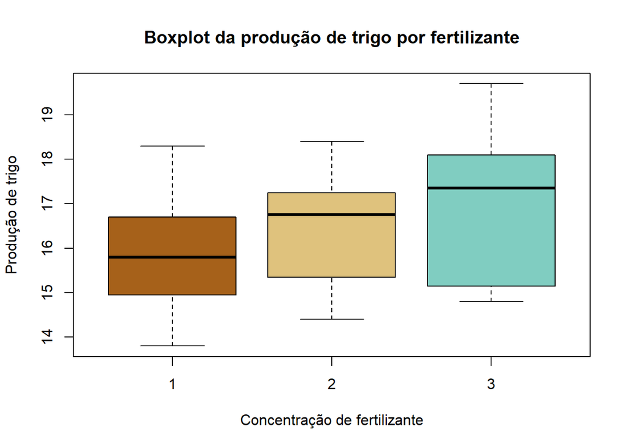

```r
library(RColorBrewer)

boxplot(Prod ~ Fert, main="Boxplot da produção de trigo por fertilizante",
        xlab="Concentração de fertilizante", ylab="Produção de trigo",
        col=brewer.pal(4, "BrBG"))
```

No gráfico acima, observamos que as Concentrações de fertilizantes 1 e 2 são semelhantes no que diz respeito a dispersão dos dados. Isso se verifica quando calculamos o desvio padrão, obtendo 1.408 e 1.382 para as Concentrações 1 e 2 respectivamente. No entanto, a média de Produção de trigo com a Concentração de fertilizante 2 é maior. Já a Concentração de fertilizante 3 é a que possui a maior média de Produção de trigo e também a maior variabilidade, tendo um desvio padrão de 1.783.

Agora vamos analisar o comportamento da Produção de trigo em relação a Variedade. Observe o gráfico abaixo.

```r
library(RColorBrewer)

tapply(Prod,Var,sd)
```

```
##         1         2         3         4
## 0.8221922 0.9208692 0.4750439 1.2432484
```

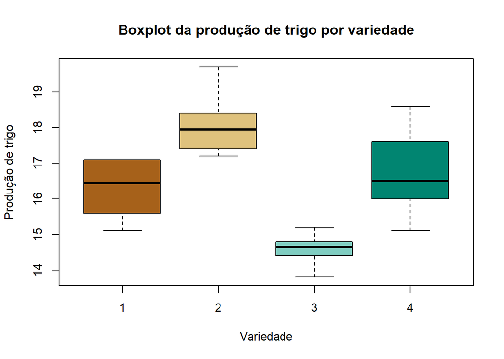

```r
boxplot(Prod ~ Var, main="Boxplot da produção de trigo por variedade",
        xlab="Variedade", ylab="Produção de trigo",
        col=brewer.pal(4, "BrBG"))
```

A nível de visualização das análises já realizadas anteriormente, veja os gráficos abaixo.

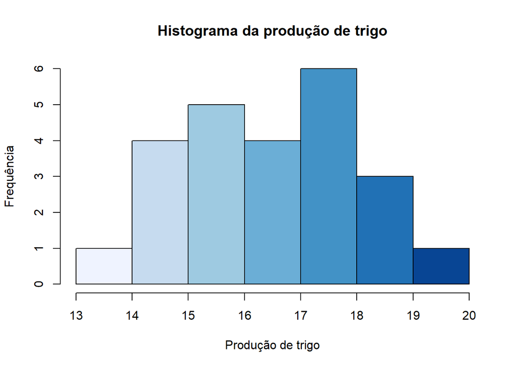

```r
library(RColorBrewer)

hist(Prod, main = "Histograma da produção de trigo", xlab="Produção de trigo",
     ylab="Frequência",  col=brewer.pal(7, "Blues"))
```

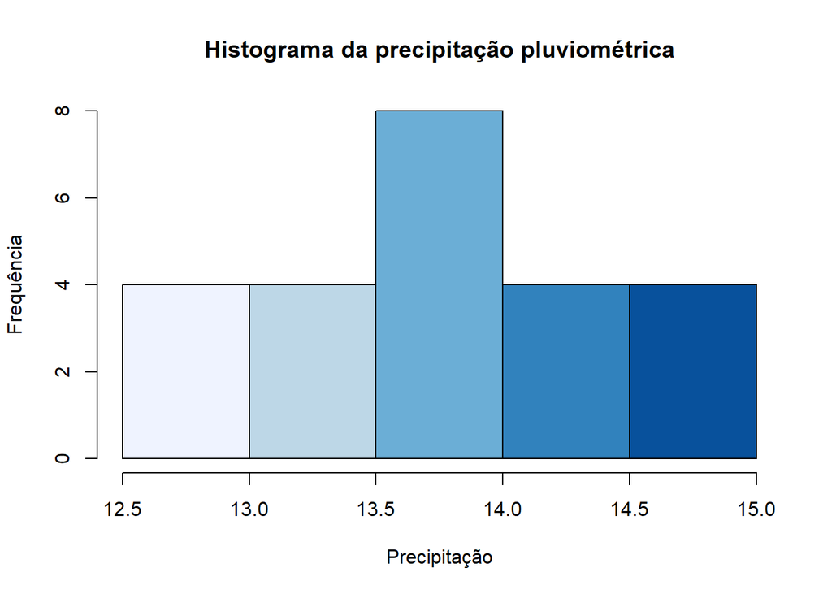

```r
hist(Prec, main = "Histograma da precipitação pluviométrica", xlab="Precipitação",
     ylab="Frequência",  col=brewer.pal(5, "Blues"))
```

Percebemos através dos histogramas acima, que os dados da Produção de trigo possuem uma certa dispersão mas a maioria se encontra entre 15 kg e 18 kg. Já quando observamos o histograma referente à Precipitação, vemos uma maior homogeneidade, e entre 13.5 cm e 14 cm se encontram um terço dos dados. O restante está distribuído igualmente entre as outras classes.

## 2.3 Correlação

Para tentar enxergar se há alguma relação entre as variáveis Produção de trigo e Precipitação, calculamos a correlação entre elas e plotamos um gráfico de dispersão.

```r
cor(Prod,Prec)
```

```
## [1] -0.09248386
```

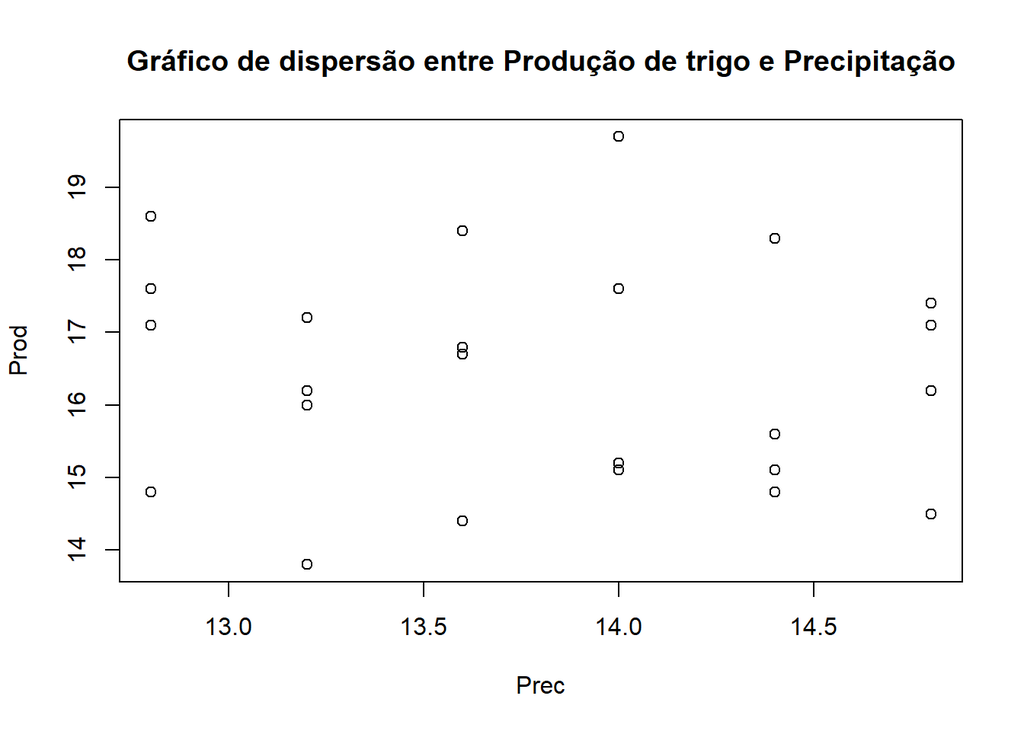

```r
plot(Prec, Prod, main="Gráfico de dispersão entre Produção de trigo e Precipitação")
```

Como observado a correlação entre as variáveis foi muito baixa (-0.0925). Vemos pelo gráfico também que elas não aparentam ter nenhuma relação muito aparente.